# Case 3: Encontrando padrões nos dados

## Um breve introdução sobre árvores de decisão

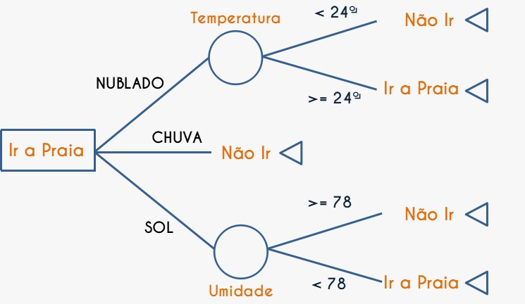

### O que é?

- É um modelo de aprendizagem de máquina supervisionado (supervised machine learning)
- Podem ser usados para problemas de regressão e classificação

### Estrutura de uma árvode de decisões

- **Raíz**: é o primeiro nó na hierarquia da árvore (nós de decisão)
- **Nó**: sãos os filho do nó raíz e representam decisões incertas (nós de probabilidade)
- **Nó folha (terminal)**: é o nó que não possui filhos e traz a decisão final (nó de desfecho)

Cada nó representa uma regra. O nó folha, por sua vez, representa a decisão a seguir no fluxo de decisões da árvore.

## Libs

```r
# install.packages("rpart")
# install.packages("rpart.plot")
# install.packages("corrplot")
```

```r
library(tidyverse)
library(sf)
```

```r
library(rpart)
library(rpart.plot)
```

## Importar os dados

```r
df <- read_sf('../dados/preparados/distritos_cultura.shp')
```

## Preparar dados para árvore

```r
1000/0
```

```
## [1] Inf
```

```r
df <- df %>%
  mutate(negros = pretos + pardos,
         brancos1000 = brancos/1000,
         negros1000 = negros/1000,
         pessoas1000 = pessoas/1000,
         equipamentos_pc = (pessoas / eqpmnts) / 10000,
         equipamentos_pc =  ifelse(is.infinite(equipamentos_pc), 0, equipamentos_pc),
         y1 = factor(eqpmnts > mean(eqpmnts), labels = c("<= Média", "> Média")),
         y2 = factor(eqpmnts == 0, labels = c("0", "> 0")),
         y3 = factor(equipamentos_pc > mean(equipamentos_pc), labels = c("<= Média", "> Média"))
         )
```

```r
df %>% names
```

```
##  [1] "cd_dstr"         "nm_dstr"         "ar_dstr"         "brancos"
##  [5] "pretos"          "amarels"         "pardos"          "indigns"
##  [9] "domicls"         "rnd_dmc"         "pessoas"         "rnd_dm_"
## [13] "rend_pc"         "bibltcs"         "espcs_c"         "museus"
## [17] "outros"          "ttr_cnm"         "eqpmnts"         "geometry"
## [21] "negros"          "brancos1000"     "negros1000"      "pessoas1000"
## [25] "equipamentos_pc" "y1"              "y2"              "y3"
```

## Explorando os dados

```r
table(df$y1)
```

```
##
## <= Média  > Média
##       75       21
```

```r
prop.table(table(df$y1))
```

```
##
## <= Média  > Média
##  0.78125  0.21875
```

```r
mean(df$eqpmnts)
```

```
## [1] 17.66667
```

```r
df %>%
  data.frame %>%
  select(contains("1000"), rnd_dm_, y1) %>%
  group_by(y1) %>%
  summarise_all(funs(mean)) %>%
  mutate_at(vars(-y1, -rnd_dm_, -pessoas1000), ~(. / sum(.))) %>%
  pivot_longer(cols=-c(y1)) %>%
  pivot_wider(names_from = y1)
```

```
## # A tibble: 4 x 3
##   name        `<= Média` `> Média`
##   <chr>            <dbl>     <dbl>
## 1 brancos1000      0.551     0.449
## 2 negros1000       0.806     0.194
## 3 pessoas1000    129.       76.5
## 4 rnd_dm_       3165.     6805.
```

```r
df %>%
  data.frame %>%
  select(contains("1000"), rnd_dm_, bibltcs, y3) %>%
  group_by(y3) %>%
  summarise_all(funs(mean)) %>%
  mutate_at(vars(-y3, -rnd_dm_, -pessoas1000, -bibltcs), ~(. / sum(.))) %>%
  pivot_longer(cols=-c(y3)) %>%
  pivot_wider(names_from = y3)
```

```
## # A tibble: 5 x 3
##   name        `<= Média` `> Média`
##   <chr>            <dbl>     <dbl>
## 1 brancos1000      0.428     0.572
## 2 negros1000       0.276     0.724
## 3 pessoas1000     90.9     154.
## 4 rnd_dm_       4967.     2553.
## 5 bibltcs          1.93      1.58
```

```r
correlations <- cor(df %>% data.frame %>% select(eqpmnts, equipamentos_pc, rnd_dm_, brancos, pretos))
knitr::kable(correlations)
```

|  | eqpmnts | equipamentos_pc | rnd_dm_ | brancos | pretos |
| --- | --- | --- | --- | --- | --- |
| eqpmnts | 1.0000000 | -0.3913602 | 0.5617032 | -0.1147936 | -0.3191103 |
| equipamentos_pc | -0.3913602 | 1.0000000 | -0.4327584 | 0.2844261 | 0.3754949 |
| rnd_dm_ | 0.5617032 | -0.4327584 | 1.0000000 | -0.1849050 | -0.5749834 |
| brancos | -0.1147936 | 0.2844261 | -0.1849050 | 1.0000000 | 0.7117470 |
| pretos | -0.3191103 | 0.3754949 | -0.5749834 | 0.7117470 | 1.0000000 |

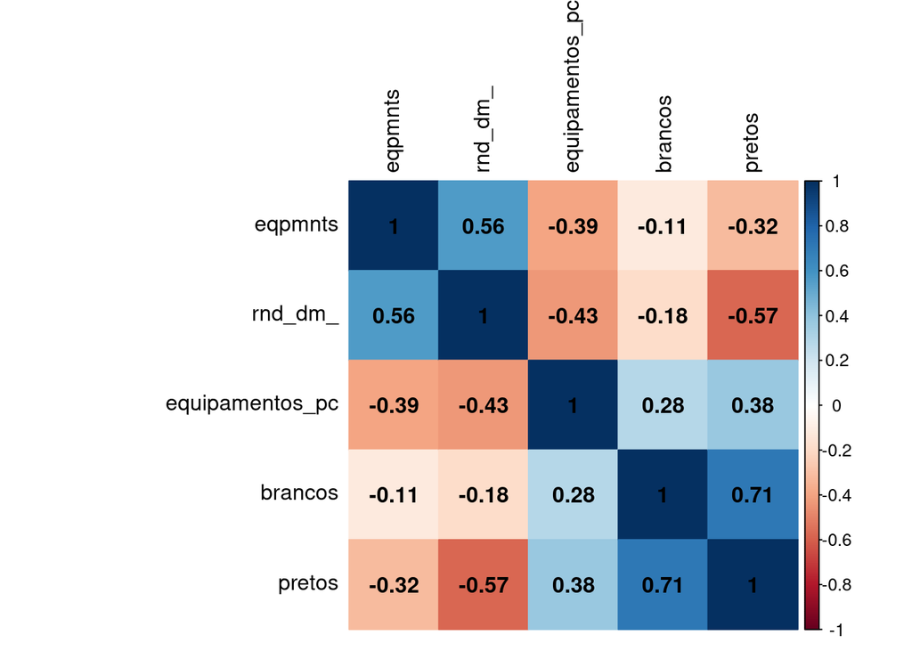

```r
library(corrplot)
corrplot(correlations,
         method="color",
         order="hclust",
         addCoef.col = "black", # Add coefficient of correlation
         tl.col="black" #Text label color and rotation
         )
```

## Árvore de decisões

### Árvore 1 - Buscando padrões

Explorar a relação entre a quantidade de pessoas negras por distrito como fato do distrito ter mais ou menos equipamentos culturais que a média municipal de equipamentos por distrito.

```r
freqs = table(df$y1)
freqs
```

```
##
## <= Média  > Média
##       75       21
```

```r
prop.table(freqs)
```

```
##
## <= Média  > Média
##  0.78125  0.21875
```

y = y1 (distritos tem ou não mais equipamentos que a média) X = negros1000

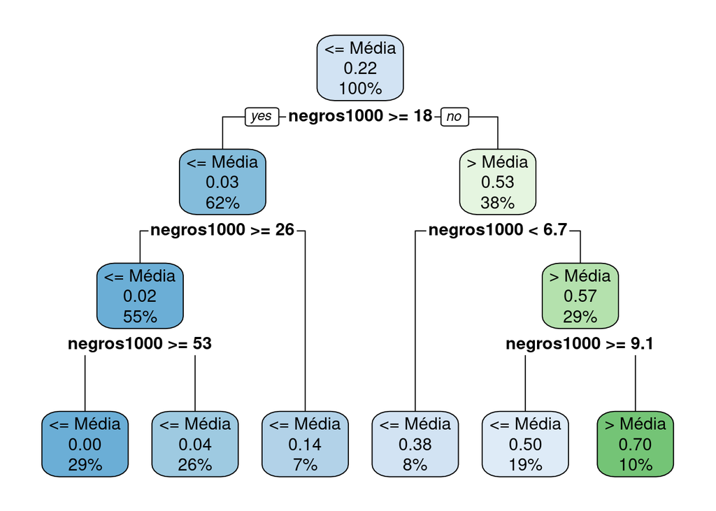

```r
library(rpart)
library(rpart.plot)

fit <- rpart(y1 ~ negros1000, data=df,
             method="class", control = rpart.control(maxdepth=3, cp=-1))

rpart.plot(fit)
```

Cada nó apresenta:

- A classe estimada
- A probabilidade estimada
- O percentual de observações que caíram no nó

```r
df %>% select(negros1000)
```

```
## Simple feature collection with 96 features and 1 field
## geometry type:  POLYGON
## dimension:      XY
## bbox:           xmin: 313394.9 ymin: 7343708 xmax: 360619.8 ymax: 7416189
## projected CRS:  SIRGAS 2000 / UTM zone 23S
## # A tibble: 96 x 2
##    negros1000                                                           geometry
##         <dbl>                                                      <POLYGON [m]>
##  1      11.7  ((338561.8 7394464, 338561.9 7394464, 338564.8 7394467, 338597.4 …
##  2       3.48 ((325006.5 7396177, 325108.6 7396178, 325117.1 7396178, 325117.2 …
##  3      33.1  ((313586.5 7410659, 313610.4 7410668, 313612.3 7410669, 313634.8 …
##  4      24.7  ((344972.5 7394014, 344984.4 7394022, 344998.6 7394033, 345011.4 …
##  5      39.0  ((349341.7 7397697, 349408.1 7397721, 349411.6 7397722, 349434.8 …
##  6       2.25 ((327682.2 7397741, 327675.9 7397752, 327674.8 7397753, 327673.1 …
##  7      15.0  ((331873.4 7394449, 331874.7 7394453, 331880.7 7394470, 331884.1 …
##  8      11.1  ((336579.3 7395217, 336227.3 7395136, 336216 7395153, 336151.4 73…
##  9      10.6  ((334062.6 7397272, 334056 7396858, 334053.8 7396717, 334052 7396…
## 10       9.79 ((335159.1 7396405, 335255.7 7396512, 335299.2 7396560, 335385.9 …
## # … with 86 more rows
```

```r
df$y1pred <- predict(fit, df %>% select(negros1000), type="class")
df$y1pred
```

```
##        1        2        3        4        5        6        7        8
## <= Média <= Média <= Média <= Média <= Média <= Média <= Média <= Média
##        9       10       11       12       13       14       15       16
## <= Média <= Média <= Média  > Média <= Média  > Média  > Média <= Média
##       17       18       19       20       21       22       23       24
## <= Média <= Média <= Média <= Média <= Média <= Média <= Média <= Média
##       25       26       27       28       29       30       31       32
## <= Média <= Média <= Média <= Média <= Média <= Média <= Média <= Média
##       33       34       35       36       37       38       39       40
## <= Média <= Média  > Média <= Média <= Média <= Média <= Média <= Média
##       41       42       43       44       45       46       47       48
## <= Média <= Média <= Média <= Média  > Média <= Média <= Média  > Média
##       49       50       51       52       53       54       55       56
## <= Média <= Média <= Média <= Média <= Média <= Média <= Média <= Média
##       57       58       59       60       61       62       63       64
## <= Média <= Média <= Média <= Média <= Média  > Média <= Média <= Média
##       65       66       67       68       69       70       71       72
## <= Média <= Média <= Média <= Média <= Média <= Média  > Média <= Média
##       73       74       75       76       77       78       79       80
## <= Média <= Média <= Média <= Média <= Média  > Média  > Média <= Média
##       81       82       83       84       85       86       87       88
## <= Média <= Média <= Média <= Média <= Média <= Média <= Média <= Média
##       89       90       91       92       93       94       95       96
## <= Média <= Média <= Média <= Média <= Média <= Média <= Média <= Média
## Levels: <= Média > Média
```

```r
df %>%
  data.frame %>%
  count(y1, y1pred)
```

```
##         y1   y1pred  n
## 1 <= Média <= Média 72
## 2 <= Média  > Média  3
## 3  > Média <= Média 14
## 4  > Média  > Média  7
```

### Árvore 2 - Buscando padrões

Explorar a relação entre a quantidade de renda domicilar e pessoas negras por distrito como fato do distrito ter mais ou menos equipamentos culturais per capita que a média municipal por distrito.

```r
mean(df$equipamentos_pc)
```

```
## [1] 2.337678
```

```r
freqs = table(df$y3)
freqs
```

```
##
## <= Média  > Média
##       56       40
```

```r
prop.table(freqs)
```

```
##
##  <= Média   > Média
## 0.5833333 0.4166667
```

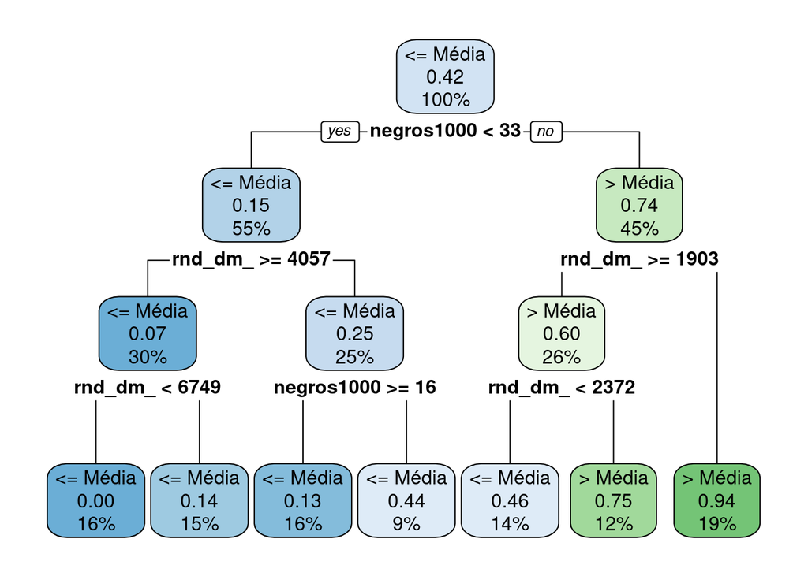

```r
library(rpart)
fit <- rpart(y3 ~ rnd_dm_ + negros1000, data=df,
             method="class", control = rpart.control(maxdepth=3, cp=-1))
rpart.plot(fit)
```

```r
df$y3pred <- predict(fit, df %>% select(rnd_dm_, negros1000), type="class")
```

```r
table(df$y3, df$y3pred)
```

```
##
##            <= Média > Média
##   <= Média       52       4
##   > Média        14      26
```

```r
prop.table(table(df$y3, df$y3pred))
```

```
##
##              <= Média    > Média
##   <= Média 0.54166667 0.04166667
##   > Média  0.14583333 0.27083333
```